# Act Report

## Act Report: Analyzing and Visualizing Findings

**Created by Odeniyi, Oluwasegun Olawale, a student with Udacity.**

Create a 250-word-minimum written report called "act_report.pdf" or "act_report.html" that communicates the insights and displays the visualization(s) produced from your wrangles data. This is to be framed as an external document, like a blog post or magazine article, for example.

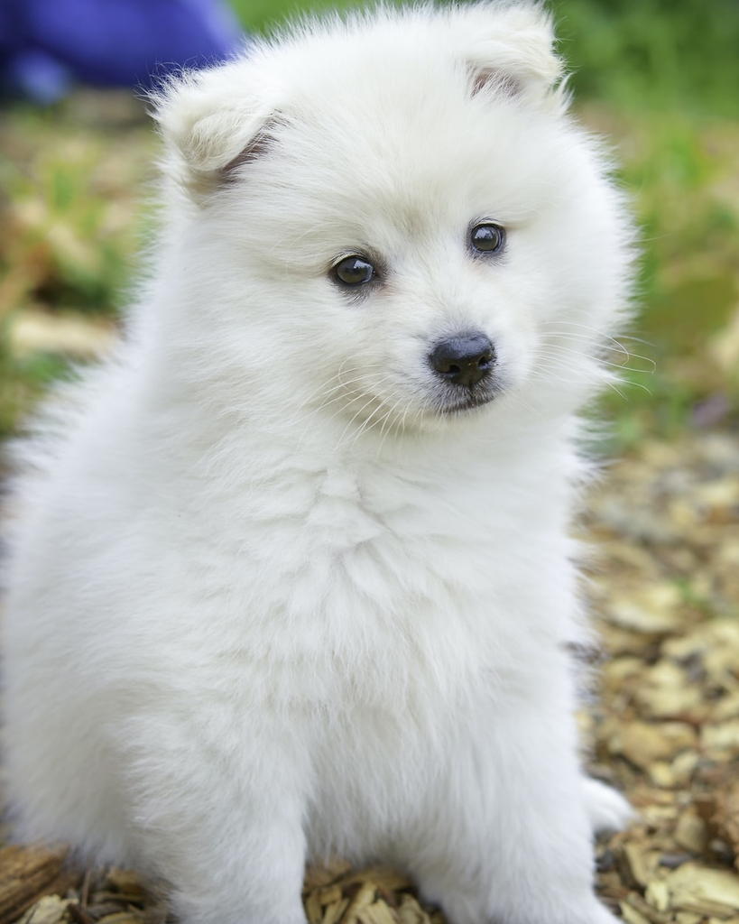

Dogs are amazing creatures. They are mostly referred to as **man's best friend**. This analysis report seeks to provide some insights into diffent kinds of dogs based on their owner's rating.

**This act report includes the summary of the Data Analysis process that was taken for the data wrangling project.**

In this project, I worked with three datasets.

Udacity provided the first dataset which is a csv file named twitter_archive_enhanced.csv. It contains basic information about 2356 tweets and was downloaded manually.

The second dataset was a tsv file named image_prediction.tsv which was hosted on udacity server and I programmatically downloaded the file. It contains 2075 predictions made by a neural network that can classify dog breeds.

For the third dataset, I downloaded data collected via the twitter API from my Udacity classroom. This third dataset contains information like the retweet count, favorite count, each tweet recieved for 2327 tweets in the file "tweet_json_text".

While assessing the data, I discovered 14 quality issues and 2 tidiness issues. I used a variety of Pandas methods to clean them up.

**Below are some insights and visualizations that I got after I merged the three datasets into a master dataset named master_data.csv.**

First I loaded the the master dataset in a pandas dataframe.

```python
import pandas as pd
master_data= pd.read_csv('master_data.csv')
```

```python
master_data.info()
```

```
<class 'pandas.core.frame.DataFrame'>
RangeIndex: 1992 entries, 0 to 1991
Data columns (total 22 columns):
 #   Column              Non-Null Count  Dtype
---  ------              --------------  -----
 0   tweet_id            1992 non-null   int64
 1   timestamp           1992 non-null   object
 2   source              1992 non-null   object
 3   text                1992 non-null   object
 4   expanded_urls       1992 non-null   object
 5   rating_numerator    1992 non-null   int64
 6   rating_denominator  1992 non-null   int64
 7   name                1348 non-null   object
 8   year                1992 non-null   int64
 9   month               1992 non-null   int64
 10  day                 1992 non-null   int64
 11  dog_stage           284 non-null    object
 12  jpg_url             1992 non-null   object
 13  img_num             1992 non-null   int64
 14  dog_breed           1684 non-null   object
 15  truncated           1992 non-null   bool
 16  is_quote_status     1992 non-null   bool
 17  retweet_count       1992 non-null   int64
 18  favorite_count      1992 non-null   int64
 19  favorited           1992 non-null   bool
 20  retweeted           1992 non-null   bool
 21  lang                1992 non-null   object
dtypes: bool(4), int64(9), object(9)
memory usage: 288.0+ KB
```

```python
master_data.describe()
```

[output not shown]

### Visualisations

**1. The most occuring number of image per dog tweet is 1**

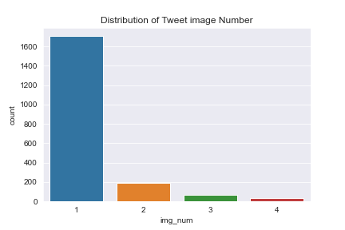

[figure not shown]

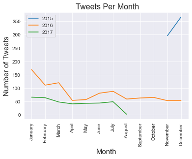

**4. From the graph below, there is a positive linear relationship between retweet_count and favorite_count.**

A reasonable hypothesis is that the most popular tweets get the highest number of retweet count and favorite count. I tested the correlation between retweet_count and favorite_count and the r^2 is 0.913. That is a high value showing a strong correlation between them.

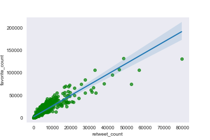

**5. The TOP 10 most retweeted and most favorited dog breeds are golden_retriever, labrador_retriever, pembroke, chihuahua, samoyed, french_bulldog, cocker_spaniel, chow, pug, toy_poodle**

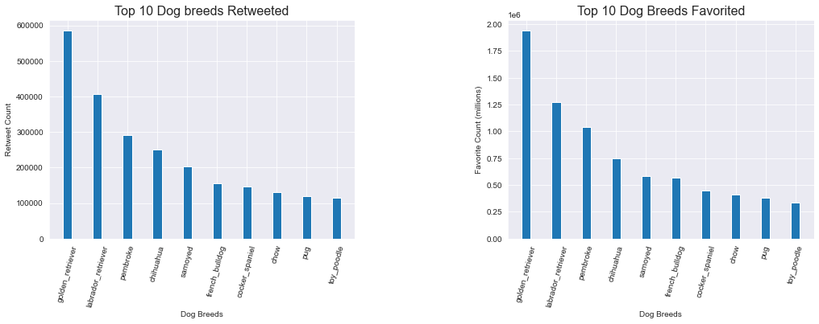

*Thanks for reading!* 😉